# Workshop 11: Propensity Scores

Wei-Hung Weng

November 4, 2016

## Instructions:

For those students taking the course for credit, the work done during this workshop *can be* be handed in for *extra credit*. Please e-mail both your `Rmd` source file and `html` output to hst953hw@mit.edu no later than Wednesday Nov 15, 2016.

*To complete the assignment, fill in necessary code in the places indicated with `# Students: Insert your code here` and text based answers `### Student Answer`*

**Before beginning**, please test to see if the Rmd file will compile on your system by clicking the “Knit HTML button” in R studio above.

You will likely find it more useful to download the Rmd and html files and use them to complete the workshop.

We will be looking at propensity score analysis in this workshop and will need two new packages: `twang` and `MatchIt`. We will also, make some standard modifications to the loaded data frame, so everyone is on the same page.

```r
#install.packages(c("twang","MatchIt")) #If you haven't installed them already
library(twang); library(MIMICbook);library(Hmisc); library(tableone); library(dplyr); library(MIMICbook); library(sjPlot); library(MatchIt)
dat <- convert.bin.fac(dat)
dat$service_unit2 <- as.character(dat$service_unit) #From last week's homework
dat$service_unit2[dat$service_unit2 %in% names(which(table(dat$service_unit)<200))] <- "Other"
dat$service_unit2 <- as.factor(dat$service_unit2)
dat$aline_flg <- as.numeric(dat$aline_flg==1)
```

As mentioned in the class, a propensity scores is simply the probability of receiving the *treatment* given the other variables. It is frequently used as a way to address concerns about confounding. There are several propensity score packages in `R` and we will use the `twang` package, as it provides a rich set of tools.

Some of this lab involves generating random variables, and it’s a good idea when that occurs to set the seed, so that your analysis is reproducible.

```r
set.seed(100)
```

The propensity score software functions similarly to logistic regression or other machine learning software you used last week. The main function is `ps`. The technical aspects will be glossed over here, but it’s essentially using stochastic gradient boosting (`gbm` method for `caret`) to try to find the optimal prediction model for `aline_flg`. Optimal in our previous work meant finding the model with the highest accuracy or AUC ROC curve. Here, we care about “balance”. We would like to create a situation that when we calculate our treatment effect, the possible confounders are balanced among treated and control groups. In other words, when calculating our treatment effect, the treatment effect is estimated under this idealized situation where the potential for any measured confounders to introduce bias into our estimate is minimized. This is sometimes hard to conceptualize, but may become a little more clear when we do an example.

As stated, the process to specify our propensity score model should look very familiar. Here we are fitting `aline_flg` on `age`, `sofa_first`, `chf_flg` and `gender_num`:

```r
scores.1 <- ps(aline_flg ~ age + sofa_first + chf_flg + gender_num,data=dat,verbose=FALSE)
```

To have a look at our balance for the confounders we considered, we use the `bal.table` function:

```r
bal.table(scores.1)$es.mean.ATE
```

```
##               tx.mn  tx.sd  ct.mn  ct.sd std.eff.sz   stat     p    ks
## age          64.309 48.120 66.530 53.181     -0.044 -1.090 0.276 0.012
## sofa_first    2.652  2.634  2.651  2.608      0.000  0.009 0.993 0.008
## chf_flg:0     0.921  0.270  0.914  0.281      0.026  0.412 0.521 0.007
## chf_flg:1     0.079  0.270  0.086  0.281     -0.026     NA    NA 0.007
## gender_num:0  0.414  0.492  0.422  0.494     -0.016  0.176 0.675 0.008
## gender_num:1  0.586  0.492  0.578  0.494      0.016     NA    NA 0.008
##              ks.pval
## age            1.000
## sofa_first     1.000
## chf_flg:0      0.521
## chf_flg:1      0.521
## gender_num:0   0.675
## gender_num:1   0.675
```

In this case, we see a brief table comparing the means of different variables (`tx.mn` and `ct.mn`), and corresponding sample standard deviations (`tx.sd` and `ct.sd`) for this weighted construct. The goal is that the means are close together, or if they are far apart, this is due to chance (assessed by the `p` column, which is a p-value). Here all p-values are large, suggesting that these variables are well balanced.

This package has some additional diagnostic plots. This is a plot showing how one of the tuning parameters (number of iterations in `gbm`) are used for each of the `es` and `ks` ways of evaluating balance:

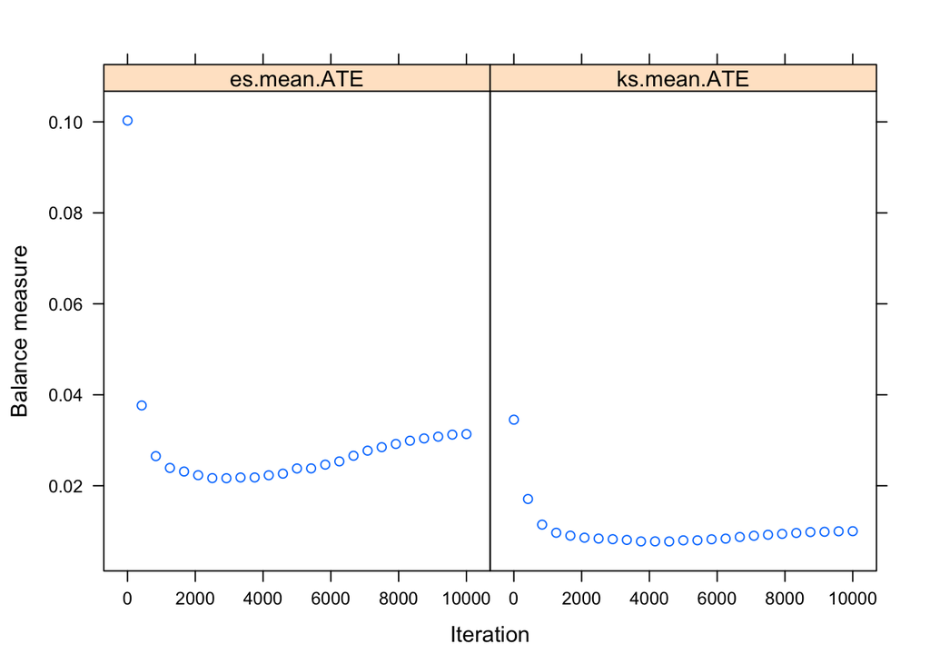

```r
plot(scores.1,plots=1)
```

Here we see our first look at the propensity scores via a boxplot. As a reminder: propensity scores are $P(aline_flg=1 | covariates)$. You can see the scores are generally higher for treatment #2:

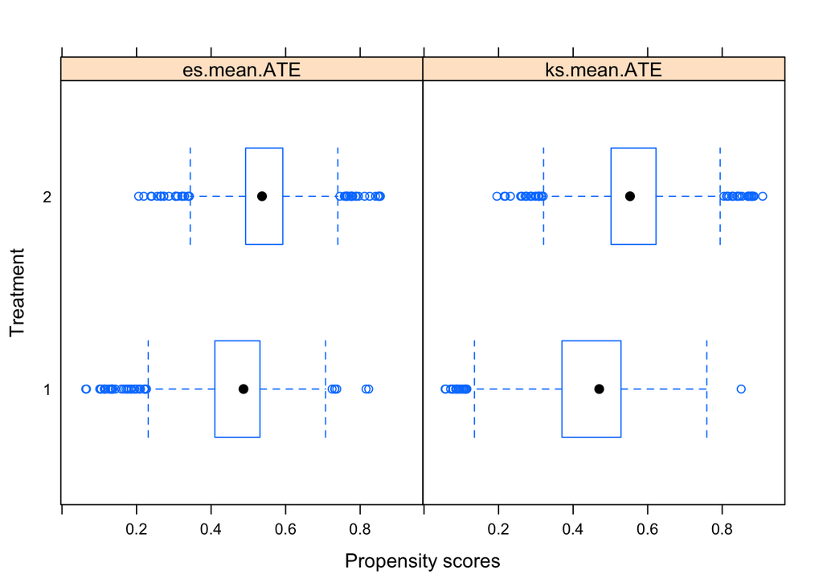

```r
plot(scores.1,plots=2)
```

Here we see how large the unbalances were for each of the variables under weighted (via functions of the propensity scores) and unweighted (naive) methods:

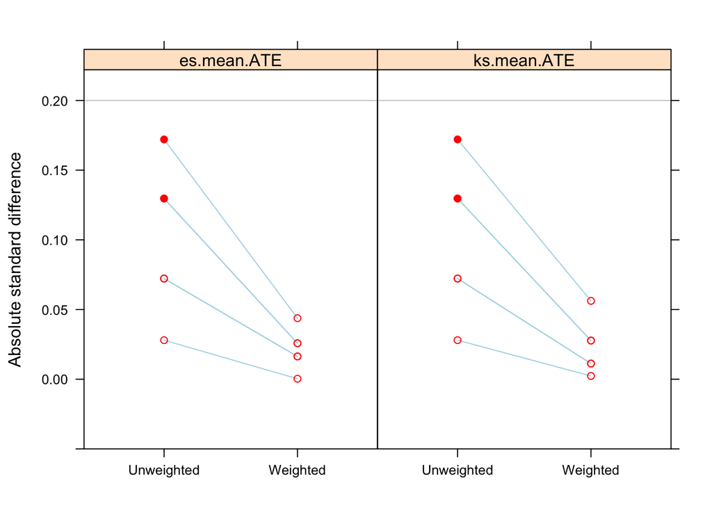

```r
plot(scores.1,plots=3)
```

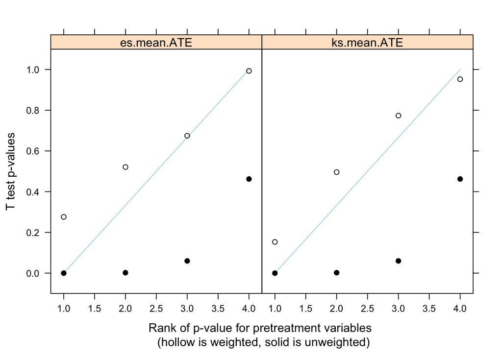

```r
plot(scores.1,plots=4)
```

We have been discussing the weights used to calculate these quantities, and here they are:

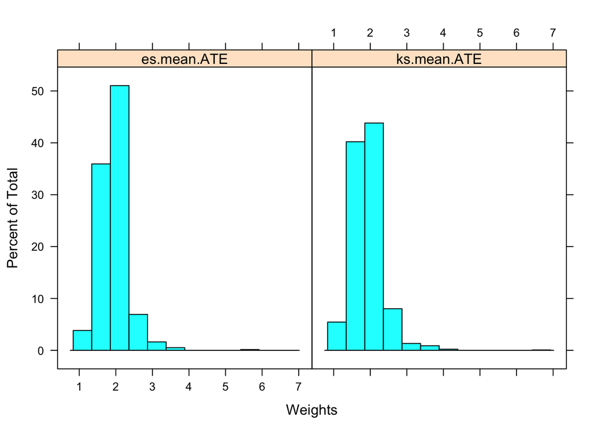

```r
plot(scores.1,plots=6)
```

# Stratified Analysis with Propensity Scores

To access the propensity scores, there is a item called `ps` in the `scores.1` object. It has two types of propensity scores, and we’ll use the `es.mean.ATE` column, and add it as a new column in our data frame. I have also divided individuals into quintiles (5 groups ranked by propensity scores), where the the lowest quintile has the lowest chance of being treated with aline, and the highest one has a the highest chance of being treated with aline.

```r
dat$ps <- scores.1$ps[,2]
dat$ps.groups <-cut2(dat$ps,g=5)
table(dat$ps.groups)
```

```
##
## [0.0637,0.435) [0.4346,0.495) [0.4949,0.530) [0.5305,0.573) [0.5729,0.854]
##            555            546            551            550            549
```

As you can see, the groups are about equally sized. The hope is that within each quintile, there is a high degree of homogeneity in each strata with respect to the confounders. We need to assess this however, and to do this, we go back to our trusty `tableone` package. Here we will assess each of the confounders within each quintile, comparing those who received an aline to those who didn’t:

```r
library(tableone);library(dplyr)

CreateTableOne(dat,vars=c("age","sofa_first","chf_flg","gender_num"),strata=c("aline_flg","ps.groups"),test=FALSE) %>% print(
  printToggle      = FALSE,
  showAllLevels    = TRUE,
  cramVars         = "kon"
) %>%
{data.frame(
  variable_name             = gsub(" ", "&nbsp;", rownames(.), fixed = TRUE), .,
  row.names        = NULL,
  check.names      = FALSE,
  stringsAsFactors = FALSE)} %>%
knitr::kable()
```

| variable_name | level | 0:[0.0637,0.435) | 1:[0.0637,0.435) | 0:[0.4346,0.495) | 1:[0.4346,0.495) | 0:[0.4949,0.530) | 1:[0.4949,0.530) | 0:[0.5305,0.573) | 1:[0.5305,0.573) | 0:[0.5729,0.854] | 1:[0.5729,0.854] |
| --- | --- | --- | --- | --- | --- | --- | --- | --- | --- | --- | --- |
| n |  | 430 | 125 | 313 | 233 | 275 | 276 | 211 | 339 | 129 | 420 |
| age (mean (sd)) |  | 99.21 (99.78) | 91.87 (96.15) | 52.39 (27.55) | 56.49 (41.04) | 56.76 (20.76) | 56.32 (29.26) | 66.03 (13.85) | 63.50 (20.99) | 57.92 (19.65) | 57.66 (24.54) |
| sofa_first (mean (sd)) |  | 2.75 (2.22) | 2.68 (1.97) | 2.36 (2.49) | 2.50 (2.37) | 2.08 (2.32) | 2.14 (2.29) | 2.88 (2.72) | 2.55 (2.66) | 3.52 (3.33) | 3.26 (3.23) |
| chf_flg (%) | 0 | 320 (74.4) | 90 (72.0) | 304 (97.1) | 215 (92.3) | 266 (96.7) | 264 (95.7) | 209 (99.1) | 327 (96.5) | 122 (94.6) | 402 (95.7) |
|  | 1 | 110 (25.6) | 35 (28.0) | 9 ( 2.9) | 18 ( 7.7) | 9 ( 3.3) | 12 ( 4.3) | 2 ( 0.9) | 12 ( 3.5) | 7 ( 5.4) | 18 ( 4.3) |
| gender_num (%) | 0 | 252 (58.6) | 75 (60.0) | 113 (36.1) | 85 (36.5) | 110 (40.0) | 119 (43.1) | 77 (36.5) | 126 (37.2) | 44 (34.1) | 157 (37.4) |
|  | 1 | 178 (41.4) | 50 (40.0) | 200 (63.9) | 148 (63.5) | 165 (60.0) | 157 (56.9) | 134 (63.5) | 213 (62.8) | 85 (65.9) | 263 (62.6) |

This table is often reported in a research report to demonstrate that you’ve balanced between treatment and control within each of the propensity score strata. Comparing pairs of columns together, you can see that within each strata, the relevant differences between treated and controls are remarkably close, while there is considerable heterogeneity between the strata. Picking the number of strata is arbitrary, and using 5 or 10 strata is very common. You should make sure your results are robust to this choice.

Evaluation can first be done visually using the tools we’ve been using thus far. We will Make a new variable `aline_flg2`, which is a factor type to make the plots look a little nicer. Using the `plot_prop_by_level` and `plot_OR_by_level` functions, we can plot the effects of `aline_flg2` by propensity score strata:

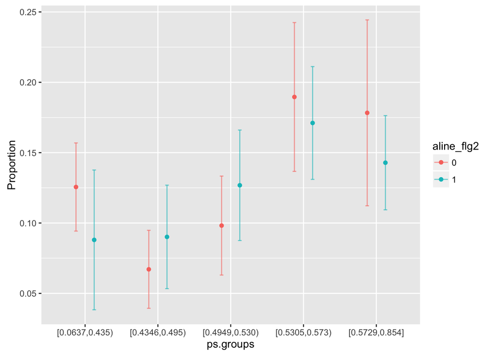

```r
dat$aline_flg2 <- as.factor(dat$aline_flg)
plot_prop_by_level(dat,"ps.groups","hosp_exp_flg",factor.var2="aline_flg2")
```

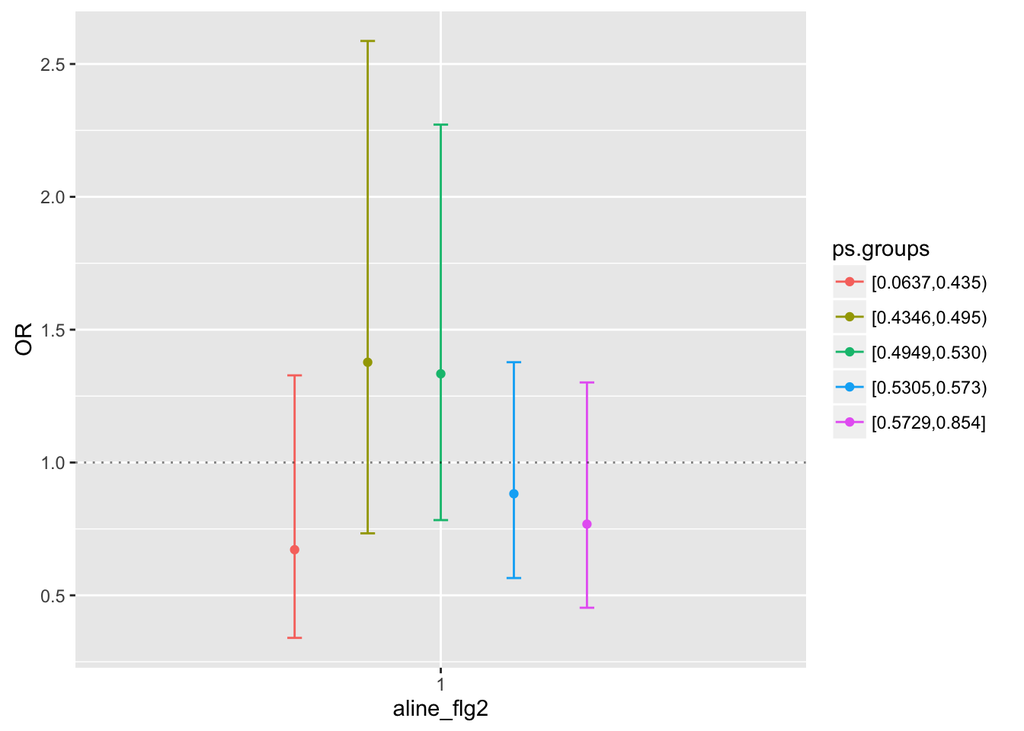

```r
plot_OR_by_level(dat,"ps.groups","hosp_exp_flg",factor.var2="aline_flg2",include.ref.group.effect = FALSE)
```

Here we are looking for consistency of effect size and/or statistical significance. The confidence intervals within each strata are fairly wide, but all include OR=1, and there is some variance in the apparent in strata effect (i.e., two groups have an apparent increase in the odds of death, where three other groups show small decreases in the odds of death).

We can pool these estimates together using logistic regression (now with our real outcome, `hosp_exp_flg`) with `aline_flg` and the propensity score strata as an additional covariate:

```r
summary(strat1.glm <- glm(hosp_exp_flg ~ aline_flg2 + ps.groups,data=dat,family="binomial"))
```

```
##
## Call:
## glm(formula = hosp_exp_flg ~ aline_flg2 + ps.groups, family = "binomial",
##     data = dat)
##
## Deviance Residuals:
##     Min       1Q   Median       3Q      Max
## -0.6333  -0.5701  -0.4931  -0.4033   2.2740
##
## Coefficients:
##                         Estimate Std. Error z value Pr(>|z|)
## (Intercept)             -2.01139    0.13480 -14.921  < 2e-16 ***
## aline_flg21             -0.03877    0.12400  -0.313  0.75456
## ps.groups[0.4346,0.495) -0.45713    0.20935  -2.184  0.02899 *
## ps.groups[0.4949,0.530) -0.03457    0.19170  -0.180  0.85690
## ps.groups[0.5305,0.573)  0.50645    0.17941   2.823  0.00476 **
## ps.groups[0.5729,0.854]  0.31561    0.19001   1.661  0.09672 .
## ---
## Signif. codes:  0 '***' 0.001 '**' 0.01 '*' 0.05 '.' 0.1 ' ' 1
##
## (Dispersion parameter for binomial family taken to be 1)
##
##     Null deviance: 2096.7  on 2750  degrees of freedom
## Residual deviance: 2066.4  on 2745  degrees of freedom
## AIC: 2078.4
##
## Number of Fisher Scoring iterations: 5
```

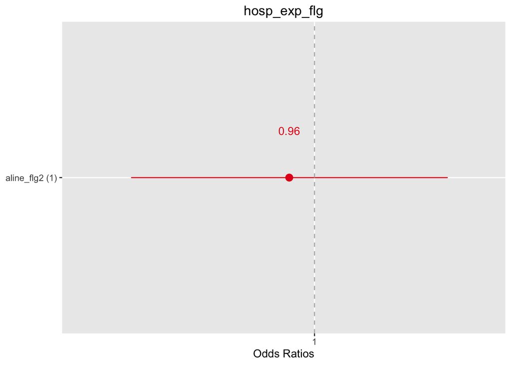

```r
sjp.glm(strat1.glm,remove.estimates = names(coef(strat1.glm))[-c(1,2)],show.p = TRUE)
```

It doesn’t seem that there is much evidence that an arterial line is associated with higher or lower mortality.

## Propensity Score Matching

While stratification is reasonably straightforward, matching is another method people use.

For each patient with a arterial line, we find one or more patients with a similar propensity score who didn’t get one, and ‘match’ these patients into a small stratum.

This step is not necessary, and is more for ease of illustration. Let’s first begin by randomly removing 500 patients who received an aline, and creating a new data frame called `dat2`

```r
dat2 <- dat[-sample(which(dat$aline_flg==1),size=500,replace=FALSE),]
```

Next, we will use the `matchit` function from the `MatchIt` package. Here we will trying to match pairs of people, one who received an aline, and one who didn’t, with close propensity scores. There are several ways to match patients, and different ways to measure closeness, but we will use the defaults (for now):

```r
match.ps1 <- matchit(aline_flg2 ~ ps,data=dat2[,c("aline_flg2","ps")],method="nearest")
match.ps1
```

```
##
## Call:
## matchit(formula = aline_flg2 ~ ps, data = dat2[, c("aline_flg2",
##     "ps")], method = "nearest")
##
## Sample sizes:
##           Control Treated
## All          1358     893
## Matched       893     893
## Unmatched     465       0
## Discarded       0       0
```

The formula should be straightforward for you to understand now, and we pass just the two columns we need to the do the matching (`aline_flg` and `ps`). You can see if we print to the console the matching object, `match.ps1`, we match every treated with a control, and have 465 unmatched controls left over. This illustrates that sometimes matching can cause wasting data.

Next, `matchit` provides a plotting method:

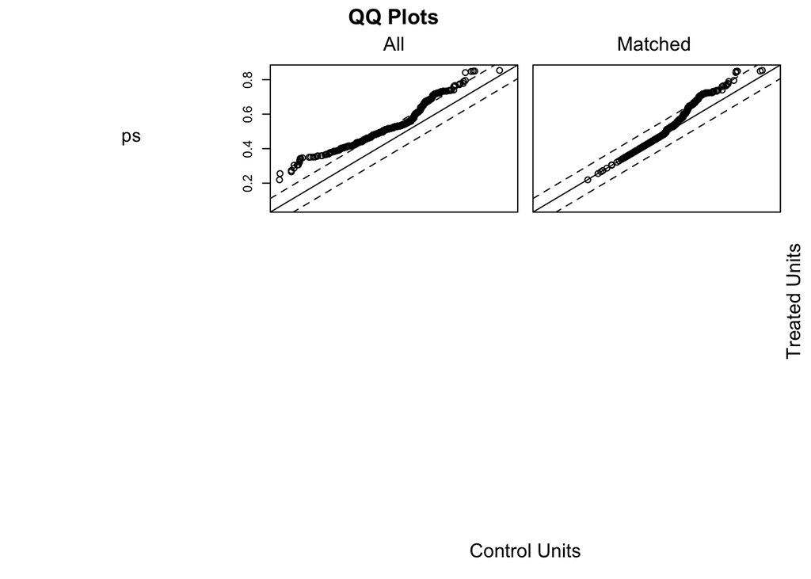

```r
plot(match.ps1)
```

Here the plot shows (by ranking in each of the treatment groups on the axes) the propensity score before matching (left,all) and after (right, matched). Ideally the individual data points are aligned on the diagonal line. Here you see we do end up with some departure for high levels of the propensity score, but it is much better than the unmatched group.

We can look at the proposed matches. The first 6 pairs by rownames are:

```r
head(match.ps1$match.matrix)
```

```
##    1
## 2  "2202"
## 6  "1375"
## 8  "2419"
## 18 "1959"
## 22 "1113"
## 23 "1723"
```

So the row named 2 in the original data frame goes with the row named 2202 To have a look at the data for these patients:

```r
dat2[row.names(dat2) %in% c(2,2202),c("aline_flg","age","sofa_first","chf_flg","gender_num","hosp_exp_flg","ps")]
```

```
##      aline_flg      age sofa_first chf_flg gender_num hosp_exp_flg
## 2            1 60.85232          0       0          1            0
## 2202         0 57.80436          0       0          1            0
##             ps
## 2    0.6285270
## 2202 0.5662104
```

SOFA and the comorbidities are exactly matched, as is `gender_num`, with the only difference being age, where the patients are about 3 years apart. Not too bad all things considered. The propensity score is 0.63 vs 0.57. You can specify the maximum distance by something called a caliper, which you will be asked to look at in the exercises.

Typically one also generates some demographic variables to illustrate the balance the propensity score matching has accomplished.

```r
CreateTableOne(dat[rownames(dat) %in% c(rownames(match.ps1$match.matrix),match.ps1$match.matrix),],
               vars=c("age","sofa_first","chf_flg","gender_num"),strata=c("aline_flg"),test=FALSE) %>% print(
  printToggle      = FALSE,
  showAllLevels    = TRUE,
  cramVars         = "kon"
) %>%
{data.frame(
  variable_name             = gsub(" ", "&nbsp;", rownames(.), fixed = TRUE), .,
  row.names        = NULL,
  check.names      = FALSE,
  stringsAsFactors = FALSE)} %>%
knitr::kable()
```

| variable_name | level | 0 | 1 |
| --- | --- | --- | --- |
| n |  | 893 | 893 |
| age (mean (sd)) |  | 59.96 (33.29) | 62.02 (42.45) |
| sofa_first (mean (sd)) |  | 2.56 (2.63) | 2.62 (2.69) |
| chf_flg (%) | 0 | 856 (95.9) | 838 (93.8) |
|  | 1 | 37 ( 4.1) | 55 ( 6.2) |
| gender_num (%) | 0 | 352 (39.4) | 361 (40.4) |
|  | 1 | 541 (60.6) | 532 (59.6) |

Evaluating the intervention (aline) among matched pairs involves bringing the pairs’ outcomes together:

```r
outcome <- data.frame(aline_pt=dat2[row.names(match.ps1$match.matrix),"hosp_exp_flg"], match_pt=dat2[match.ps1$match.matrix,"hosp_exp_flg"])
head(outcome)
```

```
##   aline_pt match_pt
## 1        0        0
## 2        0        0
## 3        0        1
## 4        1        0
## 5        1        0
## 6        1        0
```

Here you see among matched pairs the first two are concordant (both of the treated and controls lived), but the next four are discordant (one of the pair died, while the other lived.)

We can compose a 2x2 table with these paired data, but calculating an odds ratio is tricky, as this is not the same form of 2x2 table as we’ve seen before. In fact, the concordant pairs of matched pairs don’t figure into the odds ratio at all, and the odds ratio is simple the ratio of the off diagonal *counts*.

```r
tab.match1 <- table(outcome$aline_pt,outcome$match_pt,dnn=c("Aline","Matched Control"))
tab.match1
```

```
##      Matched Control
## Aline   0   1
##     0 676  93
##     1 106  18
```

```r
tab.match1[1,2]/tab.match1[2,1]
```

```
## [1] 0.8773585
```

```r
paste("95% Confint", round(exp(c(log(tab.match1[2,1]/tab.match1[1,2]) - qnorm(0.975)*sqrt(1/tab.match1[1,2] +1/tab.match1[2,1]),log(tab.match1[2,1]/tab.match1[1,2]) + qnorm(0.975)*sqrt(1/tab.match1[1,2] +1/tab.match1[2,1])) ),2))
```

```
## [1] "95% Confint 0.86" "95% Confint 1.51"
```

```r
mcnemar.test(tab.match1) # for 1-1 pairs
```

```
##
##  McNemar's Chi-squared test with continuity correction
##
## data:  tab.match1
## McNemar's chi-squared = 0.72362, df = 1, p-value = 0.395
```

The confidence interval and a relevant hypothesis test are done above, and are correct if the matching is done on pairs only. Alternative methods are available for $K$ to 1 matching, which is also quite common.

## Other Methods

There are a number of other methods which are also extremely common which use propensity scores, or a similar concept, including methods which involve weighting, or so-called ‘doubly-robust’ methods. These methods typically relying on the assumption that there is no unmeasured confounding, and are becoming more accessible with software becoming increasingly available.

### Student Questions:

> 1. We fit the propensity score model on a limited number of potential confounders. Which of the following would be easy and worthwhile to incorporate into an expanded propensity score model for `aline_flg`:
> - subject_id
> - hosp_exp_flg
> - service_unit
> - weight_first
> - mal_flg
> - map_first If not easy or worthwhile, state why.
- `service_unit`, `weight_first`, `mal_flg` and `map_first` are good to incorporate into the model because they might play roles as confounding factors related to mortality. However, `subject_id` and `hosp_exp_flg` are not ideal for adding into the propensity score model for `aline_flg`. `subject_id` is not the confounder and it is also not the covariate that should be included in the model since this is an unique identifier. `hosp_exp_flg` is the outcome variable instead of covariate.
> 2. Build a propensity score model with the `ps` function using the `dat` data frame for `aline_flg`. Regardless of your answers in a) and in addition to `age`, `sofa_first`, `chf_flg` and `gender_num`, add `service_unit2` and all the comorbitidy `flg` variables (`afib_flg` through `pneumonia_flg`, but exclude `endocarditis_flg`). Evaluate the balance using the `bal.table` function with the `es` and `ATE` option, and create a table with relevant summary statistics for *quintiles* (5 groups) of the propensity scores you just created, along with `aline_flg`. Comment on the balance.
- First we used `ps` function to create the propensity score model. The `bal.table` shows that the means are close in `tx` and `ct` groups in all variables, and p-values of all variables are greater than 0.05, which means that the model gives us a balanced model across variables.
- Next, we did stratification and made five groups approximately with equal size. In the generated table we can see that there is the homogeneity in each strata with respect to the confounders since the difference between treatement and control groups are small.
- Therefore we can say that the propensity approach helps us balancing the data.

```r
set.seed(777)
co_flg <- colnames(dat)[c(40:47, 49, 50)]
p <- ps(aline_flg ~ age + sofa_first + gender_num + service_unit2 + chf_flg + afib_flg + renal_flg + liver_flg + copd_flg + cad_flg + stroke_flg + mal_flg + resp_flg + ards_flg + pneumonia_flg,
        data=dat, verbose=FALSE)

bal.table(p)$es.mean.ATE
```

```
##                      tx.mn  tx.sd  ct.mn  ct.sd std.eff.sz   stat     p
## age                 64.111 47.683 66.543 53.935     -0.048 -1.117 0.264
## sofa_first           2.665  2.628  2.595  2.559      0.027  0.657 0.511
## gender_num:0         0.424  0.494  0.422  0.494      0.005  0.013 0.908
## gender_num:1         0.576  0.494  0.578  0.494     -0.005     NA    NA
## service_unit2:MED    0.351  0.477  0.399  0.490     -0.101  1.668 0.140
## service_unit2:NMED   0.130  0.336  0.133  0.340     -0.011     NA    NA
## service_unit2:NSURG  0.105  0.306  0.097  0.296      0.025     NA    NA
## service_unit2:Other  0.123  0.328  0.120  0.324      0.010     NA    NA
## service_unit2:SURG   0.085  0.279  0.063  0.243      0.079     NA    NA
## service_unit2:TRAUM  0.206  0.405  0.188  0.390      0.046     NA    NA
## chf_flg:0            0.919  0.273  0.913  0.283      0.023  0.298 0.585
## chf_flg:1            0.081  0.273  0.087  0.283     -0.023     NA    NA
## afib_flg:0           0.854  0.353  0.859  0.348     -0.014  0.109 0.741
## afib_flg:1           0.146  0.353  0.141  0.348      0.014     NA    NA
## renal_flg:0          0.941  0.236  0.931  0.253      0.040  0.832 0.362
## renal_flg:1          0.059  0.236  0.069  0.253     -0.040     NA    NA
## liver_flg:0          0.939  0.239  0.952  0.215     -0.052  1.884 0.170
## liver_flg:1          0.061  0.239  0.048  0.215      0.052     NA    NA
## copd_flg:0           0.986  0.118  0.980  0.141      0.053  0.918 0.338
## copd_flg:1           0.014  0.118  0.020  0.141     -0.053     NA    NA
## cad_flg:0            0.864  0.343  0.871  0.335     -0.022  0.278 0.598
## cad_flg:1            0.136  0.343  0.129  0.335      0.022     NA    NA
## stroke_flg:0         0.852  0.355  0.865  0.342     -0.037  0.829 0.363
## stroke_flg:1         0.148  0.355  0.135  0.342      0.037     NA    NA
## mal_flg:0            0.858  0.350  0.854  0.353      0.010  0.050 0.823
## mal_flg:1            0.142  0.350  0.146  0.353     -0.010     NA    NA
## resp_flg:0           0.649  0.477  0.654  0.476     -0.012  0.078 0.780
## resp_flg:1           0.351  0.477  0.346  0.476      0.012     NA    NA
## ards_flg:0           0.983  0.128  0.983  0.131      0.006  0.019 0.890
## ards_flg:1           0.017  0.128  0.017  0.131     -0.006     NA    NA
## pneumonia_flg:0      0.827  0.379  0.828  0.377     -0.005  0.014 0.906
## pneumonia_flg:1      0.173  0.379  0.172  0.377      0.005     NA    NA
##                        ks ks.pval
## age                 0.016   0.997
## sofa_first          0.015   0.999
## gender_num:0        0.002   0.908
## gender_num:1        0.002   0.908
## service_unit2:MED   0.048   0.140
## service_unit2:NMED  0.004   0.140
```

[output cut: 11 more lines]

```
## liver_flg:1         0.012   0.170
## copd_flg:0          0.006   0.338
## copd_flg:1          0.006   0.338
## cad_flg:0           0.007   0.598
## cad_flg:1           0.007   0.598
## stroke_flg:0        0.013   0.363
## stroke_flg:1        0.013   0.363
## mal_flg:0           0.003   0.823
## mal_flg:1           0.003   0.823
## resp_flg:0          0.006   0.780
## resp_flg:1          0.006   0.780
## ards_flg:0          0.001   0.890
## ards_flg:1          0.001   0.890
## pneumonia_flg:0     0.002   0.906
## pneumonia_flg:1     0.002   0.906
```

```r
dat$ps <- p$ps[, 2]
dat$ps.groups <- cut2(dat$ps, g=5)
table(dat$ps.groups)
```

```
##
## [0.0305,0.268) [0.2677,0.427) [0.4267,0.610) [0.6096,0.715) [0.7148,0.968]
##            552            549            550            550            550
```

```r
CreateTableOne(dat, vars=c("age", "sofa_first", "chf_flg", "gender_num", co_flg),
               strata=c("aline_flg", "ps.groups"),test=FALSE) %>% print(
  printToggle      = FALSE,
  showAllLevels    = TRUE,
  cramVars         = "kon"
) %>%
{data.frame(
  variable_name    = gsub(" ", "&nbsp;", rownames(.), fixed = TRUE), .,
  row.names        = NULL,
  check.names      = FALSE,
  stringsAsFactors = FALSE)} %>%
knitr::kable()
```

| variable_name | level | 0:[0.0305,0.268) | 1:[0.0305,0.268) | 0:[0.2677,0.427) | 1:[0.2677,0.427) | 0:[0.4267,0.610) | 1:[0.4267,0.610) | 0:[0.6096,0.715) | 1:[0.6096,0.715) | 0:[0.7148,0.968] | 1:[0.7148,0.968] |
| --- | --- | --- | --- | --- | --- | --- | --- | --- | --- | --- | --- |
| n |  | 482 | 70 | 369 | 180 | 268 | 282 | 177 | 373 | 62 | 488 |
| age (mean (sd)) |  | 86.65 (86.42) | 84.46 (85.38) | 67.27 (45.74) | 62.55 (30.16) | 57.89 (45.20) | 60.01 (52.73) | 58.12 (25.85) | 59.69 (31.99) | 59.30 (16.46) | 60.60 (30.16) |
| sofa_first (mean (sd)) |  | 2.47 (2.33) | 2.21 (1.86) | 3.05 (2.72) | 3.21 (2.66) | 2.19 (2.41) | 2.31 (2.74) | 2.71 (2.73) | 2.38 (2.58) | 2.74 (2.65) | 3.02 (2.84) |
| chf_flg (%) | 0 | 419 (86.9) | 62 ( 88.6) | 327 (88.6) | 160 (88.9) | 250 (93.3) | 256 (90.8) | 164 ( 92.7) | 346 (92.8) | 61 ( 98.4) | 474 ( 97.1) |
|  | 1 | 63 (13.1) | 8 ( 11.4) | 42 (11.4) | 20 (11.1) | 18 ( 6.7) | 26 ( 9.2) | 13 ( 7.3) | 27 ( 7.2) | 1 ( 1.6) | 14 ( 2.9) |
| gender_num (%) | 0 | 232 (48.1) | 32 ( 45.7) | 175 (47.4) | 90 (50.0) | 97 (36.2) | 118 (41.8) | 68 ( 38.4) | 140 (37.5) | 24 ( 38.7) | 182 ( 37.3) |
|  | 1 | 250 (51.9) | 38 ( 54.3) | 194 (52.6) | 90 (50.0) | 171 (63.8) | 164 (58.2) | 109 ( 61.6) | 233 (62.5) | 38 ( 61.3) | 306 ( 62.7) |
| afib_flg (%) | 0 | 401 (83.2) | 54 ( 77.1) | 314 (85.1) | 163 (90.6) | 235 (87.7) | 239 (84.8) | 152 ( 85.9) | 310 (83.1) | 55 ( 88.7) | 431 ( 88.3) |
|  | 1 | 81 (16.8) | 16 ( 22.9) | 55 (14.9) | 17 ( 9.4) | 33 (12.3) | 43 (15.2) | 25 ( 14.1) | 63 (16.9) | 7 ( 11.3) | 57 ( 11.7) |
| renal_flg (%) | 0 | 424 (88.0) | 61 ( 87.1) | 338 (91.6) | 169 (93.9) | 248 (92.5) | 259 (91.8) | 176 ( 99.4) | 363 (97.3) | 60 ( 96.8) | 474 ( 97.1) |
|  | 1 | 58 (12.0) | 9 ( 12.9) | 31 ( 8.4) | 11 ( 6.1) | 20 ( 7.5) | 23 ( 8.2) | 1 ( 0.6) | 10 ( 2.7) | 2 ( 3.2) | 14 ( 2.9) |
| liver_flg (%) | 0 | 460 (95.4) | 69 ( 98.6) | 335 (90.8) | 161 (89.4) | 256 (95.5) | 266 (94.3) | 175 ( 98.9) | 364 (97.6) | 59 ( 95.2) | 441 ( 90.4) |
|  | 1 | 22 ( 4.6) | 1 ( 1.4) | 34 ( 9.2) | 19 (10.6) | 12 ( 4.5) | 16 ( 5.7) | 2 ( 1.1) | 9 ( 2.4) | 3 ( 4.8) | 47 ( 9.6) |
| copd_flg (%) | 0 | 445 (92.3) | 65 ( 92.9) | 367 (99.5) | 178 (98.9) | 266 (99.3) | 281 (99.6) | 177 (100.0) | 372 (99.7) | 62 (100.0) | 488 (100.0) |
|  | 1 | 37 ( 7.7) | 5 ( 7.1) | 2 ( 0.5) | 2 ( 1.1) | 2 ( 0.7) | 1 ( 0.4) | 0 ( 0.0) | 1 ( 0.3) | 0 ( 0.0) | 0 ( 0.0) |
| cad_flg (%) | 0 | 429 (89.0) | 61 ( 87.1) | 325 (88.1) | 160 (88.9) | 234 (87.3) | 256 (90.8) | 153 ( 86.4) | 314 (84.2) | 50 ( 80.6) | 402 ( 82.4) |
|  | 1 | 53 (11.0) | 9 ( 12.9) | 44 (11.9) | 20 (11.1) | 34 (12.7) | 26 ( 9.2) | 24 ( 13.6) | 59 (15.8) | 12 ( 19.4) | 86 ( 17.6) |
| stroke_flg (%) | 0 | 466 (96.7) | 70 (100.0) | 347 (94.0) | 177 (98.3) | 205 (76.5) | 226 (80.1) | 140 ( 79.1) | 274 (73.5) | 52 ( 83.9) | 394 ( 80.7) |
|  | 1 | 16 ( 3.3) | 0 ( 0.0) | 22 ( 6.0) | 3 ( 1.7) | 63 (23.5) | 56 (19.9) | 37 ( 20.9) | 99 (26.5) | 10 ( 16.1) | 94 ( 19.3) |
| mal_flg (%) | 0 | 414 (85.9) | 60 ( 85.7) | 306 (82.9) | 154 (85.6) | 231 (86.2) | 244 (86.5) | 161 ( 91.0) | 321 (86.1) | 48 ( 77.4) | 413 ( 84.6) |
|  | 1 | 68 (14.1) | 10 ( 14.3) | 63 (17.1) | 26 (14.4) | 37 (13.8) | 38 (13.5) | 16 ( 9.0) | 52 (13.9) | 14 ( 22.6) | 75 ( 15.4) |
| resp_flg (%) | 0 | 291 (60.4) | 40 ( 57.1) | 159 (43.1) | 70 (38.9) | 199 (74.3) | 209 (74.1) | 146 ( 82.5) | 288 (77.2) | 45 ( 72.6) | 354 ( 72.5) |
|  | 1 | 191 (39.6) | 30 ( 42.9) | 210 (56.9) | 110 (61.1) | 69 (25.7) | 73 (25.9) | 31 ( 17.5) | 85 (22.8) | 17 ( 27.4) | 134 ( 27.5) |
| ards_flg (%) | 0 | 469 (97.3) | 69 ( 98.6) | 362 (98.1) | 173 (96.1) | 263 (98.1) | 277 (98.2) | 176 ( 99.4) | 370 (99.2) | 61 ( 98.4) | 485 ( 99.4) |
|  | 1 | 13 ( 2.7) | 1 ( 1.4) | 7 ( 1.9) | 7 ( 3.9) | 5 ( 1.9) | 5 ( 1.8) | 1 ( 0.6) | 3 ( 0.8) | 1 ( 1.6) | 3 ( 0.6) |
| pneumonia_flg (%) | 0 | 399 (82.8) | 62 ( 88.6) | 252 (68.3) | 123 (68.3) | 232 (86.6) | 235 (83.3) | 159 ( 89.8) | 332 (89.0) | 56 ( 90.3) | 421 ( 86.3) |
|  | 1 | 83 (17.2) | 8 ( 11.4) | 117 (31.7) | 57 (31.7) | 36 (13.4) | 47 (16.7) | 18 ( 10.2) | 41 (11.0) | 6 ( 9.7) | 67 ( 13.7) |

> 3. Create relevant plots to assess if aline_flg affects mortality within each strata. Do these plots differ from the ones in the smaller set of covariates. If so how?
- Yes, the plots look much homogeneous and the confidence intervals are much wider within each stratum. However, the confidence intervals still include OR=1 in all strata (with / without aline), and there are also more overlapping (less variance) between strata except the group with lowest propensity score.
- This may indicate that after adjusting confounding factors, the model is more balanced, and it’s much more confident to say that there is no evidence that an arterial line is associated with in hospital mortality.

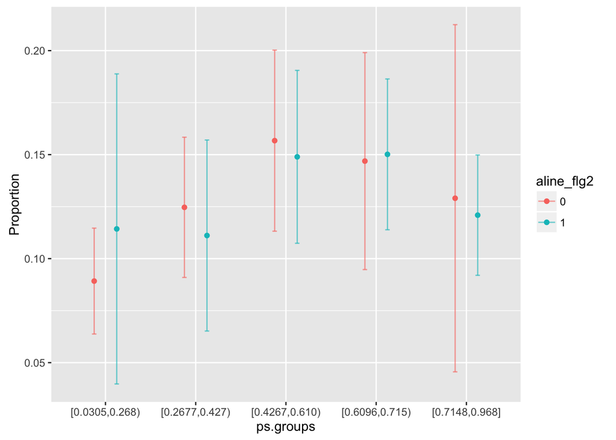

```r
dat$aline_flg2 <- as.factor(dat$aline_flg)
plot_prop_by_level(dat, "ps.groups", "hosp_exp_flg", factor.var2="aline_flg2")
```

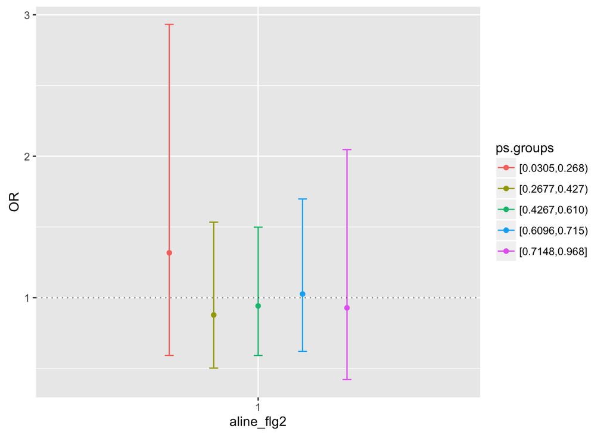

```r
plot_OR_by_level(dat, "ps.groups", "hosp_exp_flg", factor.var2="aline_flg2",
                 include.ref.group.effect = FALSE)
```

> 4. Aggregate the estimates across strata to estimate an overall odds ratio.
- The overall odds ratio is 0.98, and the confidence interval includes OR=1.0. So we can still conclude that the aline has no enough evidence to be associated with mortality.

```r
summary(st <- glm(hosp_exp_flg ~ aline_flg2 + ps.groups, data=dat, family="binomial"))
```

```
##
## Call:
## glm(formula = hosp_exp_flg ~ aline_flg2 + ps.groups, family = "binomial",
##     data = dat)
##
## Deviance Residuals:
##     Min       1Q   Median       3Q      Max
## -0.5787  -0.5664  -0.5091  -0.4409   2.1904
##
## Coefficients:
##                         Estimate Std. Error z value Pr(>|z|)
## (Intercept)             -2.28205    0.14789 -15.431  < 2e-16 ***
## aline_flg21             -0.02172    0.13264  -0.164  0.86996
## ps.groups[0.2677,0.427)  0.29877    0.19879   1.503  0.13286
## ps.groups[0.4267,0.610)  0.57977    0.19556   2.965  0.00303 **
## ps.groups[0.6096,0.715)  0.55499    0.20310   2.733  0.00628 **
## ps.groups[0.7148,0.968]  0.32597    0.22085   1.476  0.13994
## ---
## Signif. codes:  0 '***' 0.001 '**' 0.01 '*' 0.05 '.' 0.1 ' ' 1
##
## (Dispersion parameter for binomial family taken to be 1)
##
##     Null deviance: 2096.7  on 2750  degrees of freedom
## Residual deviance: 2084.4  on 2745  degrees of freedom
## AIC: 2096.4
##
## Number of Fisher Scoring iterations: 4
```

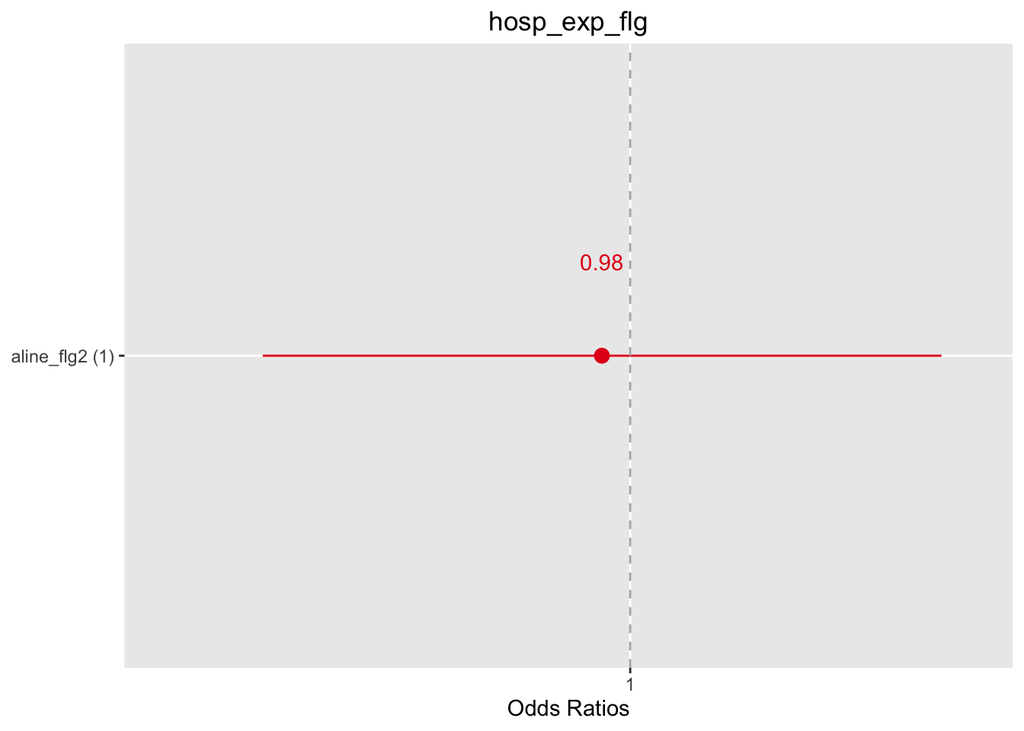

```r
sjp.glm(st, remove.estimates=names(coef(st))[-c(1, 2)], show.p=TRUE)
```

> 5. Using these newly generated propensity scores, with the `matchit` function and an additional argument (caliper=0.2), match the entire cohort (i.e., do no remove any patients). If you get an error, determine why the error occurred, and explain in words why it occurred, but ignore it for subsequent work. Assess with data visualiztion and appropriate tables, how well the matched pairs are balanced across the covariates considered. Is this better than the work above (`match.ps1`)? Is the sample size of matched pairs larger or smaller? Why?
- The warning message comes from the problem of replacement. It is because that the control group is smaller than treated group (1358 vs. 1393). Some patients in the treated group will not be matched at all in the matching process (one-to-one matching).

```
Warning message:
In matchit2nearest(c(1L, 2L, 2L, 1L, 2L, 2L, 2L, 2L, 1L, 2L, 1L,  :
  Fewer control than treated units and matching without replacement.
  Not all treated units will receive a match.
  Treated units will be matched in the order specified by m.order: largest
```

- The propensity score model gives us much balanced treatment and control groups. We can use the plot and see that the data points are aligned on the diagonal line after matching, and it is better than the previous `match.ps1` model because that the data points now are much closer to diagonal line. We can also use the table to know that the treatment and control groups are homogeneous across the covariates. However, the sample size of matched pairs becomes smaller comparing to `match.ps1` model because that we have added `caliper=0.2` argument in the new model. `caliper` argument made the restriction on maximum distance. Therefore, the initially matched pairs violate the distance restriction may be tagged as unmatched.

```r
set.seed(777)
match.p <- matchit(aline_flg2 ~ ps, data=dat[, c("aline_flg2", "ps")], method="nearest", caliper=0.2)
```

```
## Warning in matchit2nearest(structure(c(1L, 2L, 2L, 1L, 2L, 2L, 2L, 2L,
## 1L, : Fewer control than treated units and matching without replacement.
## Not all treated units will receive a match. Treated units will be matched
## in the order specified by m.order: largest
```

```r
match.p
```

```
##
## Call:
## matchit(formula = aline_flg2 ~ ps, data = dat[, c("aline_flg2",
##     "ps")], method = "nearest", caliper = 0.2)
##
## Sample sizes:
##           Control Treated
## All          1358    1393
## Matched       776     776
## Unmatched     582     617
## Discarded       0       0
```

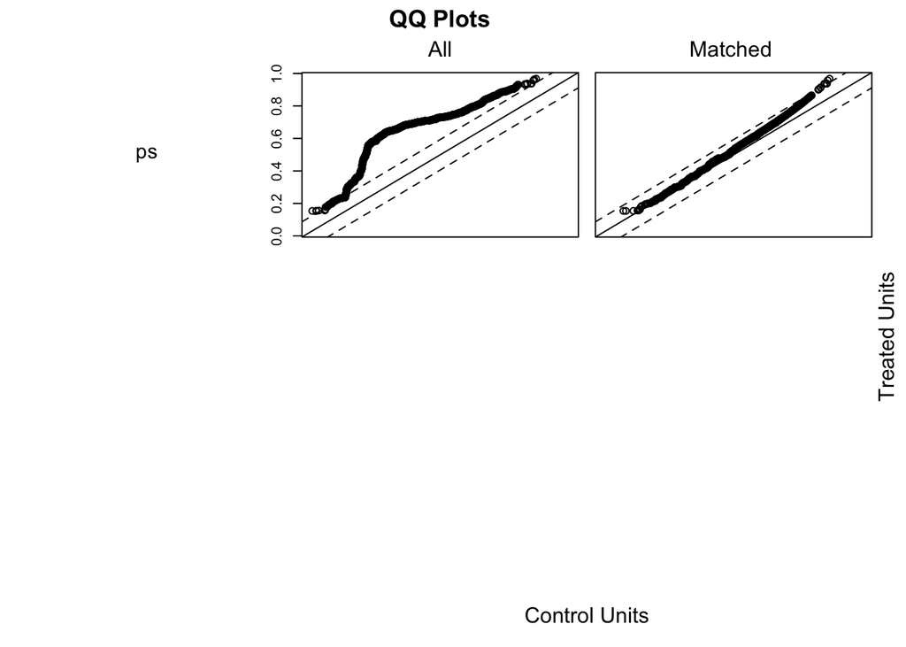

```r
plot(match.p)
```

```r
CreateTableOne(dat[rownames(dat) %in% c(rownames(match.p$match.matrix), match.p$match.matrix),],
               vars=c("age","sofa_first","chf_flg","gender_num", co_flg),
               strata=c("aline_flg"),test=FALSE) %>% print(
  printToggle      = FALSE,
  showAllLevels    = TRUE,
  cramVars         = "kon"
) %>%
{data.frame(
  variable_name             = gsub(" ", "&nbsp;", rownames(.), fixed = TRUE), .,
  row.names        = NULL,
  check.names      = FALSE,
  stringsAsFactors = FALSE)} %>%
knitr::kable()
```

| variable_name | level | 0 | 1 |
| --- | --- | --- | --- |
| n |  | 776 | 1393 |
| age (mean (sd)) |  | 64.60 (51.01) | 61.69 (40.74) |
| sofa_first (mean (sd)) |  | 2.60 (2.60) | 2.69 (2.71) |
| chf_flg (%) | 0 | 710 (91.5) | 1298 (93.2) |
|  | 1 | 66 ( 8.5) | 95 ( 6.8) |
| gender_num (%) | 0 | 321 (41.4) | 562 (40.3) |
|  | 1 | 455 (58.6) | 831 (59.7) |
| afib_flg (%) | 0 | 677 (87.2) | 1197 (85.9) |
|  | 1 | 99 (12.8) | 196 (14.1) |
| renal_flg (%) | 0 | 728 (93.8) | 1326 (95.2) |
|  | 1 | 48 ( 6.2) | 67 ( 4.8) |
| liver_flg (%) | 0 | 735 (94.7) | 1301 (93.4) |
|  | 1 | 41 ( 5.3) | 92 ( 6.6) |
| copd_flg (%) | 0 | 767 (98.8) | 1384 (99.4) |
|  | 1 | 9 ( 1.2) | 9 ( 0.6) |
| cad_flg (%) | 0 | 675 (87.0) | 1193 (85.6) |
|  | 1 | 101 (13.0) | 200 (14.4) |
| stroke_flg (%) | 0 | 652 (84.0) | 1141 (81.9) |
|  | 1 | 124 (16.0) | 252 (18.1) |
| mal_flg (%) | 0 | 672 (86.6) | 1192 (85.6) |
|  | 1 | 104 (13.4) | 201 (14.4) |
| resp_flg (%) | 0 | 510 (65.7) | 961 (69.0) |
|  | 1 | 266 (34.3) | 432 (31.0) |
| ards_flg (%) | 0 | 758 (97.7) | 1374 (98.6) |
|  | 1 | 18 ( 2.3) | 19 ( 1.4) |
| pneumonia_flg (%) | 0 | 634 (81.7) | 1173 (84.2) |
|  | 1 | 142 (18.3) | 220 (15.8) |

> 6. Using the matched pairs, estimate an odds ratio, confidence interval, and p-value for the effect of aline.
- Based on the matched pairs, the odds ratio is 0.9583333, 95% confidence interval is [0.78, 1.39] and the p-value is much greater than 0.05 (0.8268), which means that the result can’t reject the null hypothesis that aline has association with mortality.

```r
outcome <- data.frame(aline_pt=dat[row.names(match.p$match.matrix), "hosp_exp_flg"],
                      match_pt=dat[match.p$match.matrix, "hosp_exp_flg"])
head(outcome)
```

```
##   aline_pt match_pt
## 1        0        0
## 2        0        0
## 3        0     <NA>
## 4        0        0
## 5        0     <NA>
## 6        0        0
```

```r
(tab <- table(outcome$aline_pt, outcome$match_pt, dnn=c("Aline","Matched Control")))
```

```
##      Matched Control
## Aline   0   1
##     0 573  92
##     1  96  15
```

```r
tab[1, 2] / tab[2, 1]
```

```
## [1] 0.9583333
```

```r
paste("95% Confint", round(exp(c(log(tab[2, 1] / tab[1, 2]) - qnorm(0.975)*sqrt(1/tab[1, 2] + 1 / tab[2, 1]),
                                 log(tab[2, 1] / tab[1, 2]) + qnorm(0.975)*sqrt(1/tab[1, 2] + 1 / tab[2,1 ])) ),
                           2))
```

```
## [1] "95% Confint 0.78" "95% Confint 1.39"
```

```r
mcnemar.test(tab)
```

```
##
##  McNemar's Chi-squared test with continuity correction
##
## data:  tab
## McNemar's chi-squared = 0.047872, df = 1, p-value = 0.8268
```

> 7. Repeat (e-f) but with caliper=0.1. Briefly comment on the trade offs which occur when you change the caliper size. Use more values of calipers if necessary. You do not need to include any of the code or output in your submission for this part.
- If we decrease the `caliper` from 0.2 to 0.1, less matched pairs are identified because that `caliper=0.1` means much restrict pairing distance. However, the confounding factors in treatment and control groups become more homogeneous since the data points in the plot are closer to diagonal line. The result also can’t reject the null hypothesis (OR is closer to 1, 95% CI still includes OR=1, and p-value is greater than 0.05 (0.9412)).
- If we increase `caliper` argument from 0.2 to 0.5, which means that we use loosen restriction for matching. The groups become less homogeneous, and we can check this through the plot that the data points are deviated from diagonal line. More matched pairs was identified. However, the statistical tests are still not significant. 95% CI still includes OR=1 and p-value is greater than 0.05 (0.5116).

```r
# 0.1
set.seed(777)
match.p <- matchit(aline_flg2 ~ ps, data=dat[, c("aline_flg2","ps")], method="nearest", caliper=0.1)
match.p
```

```
##
## Call:
## matchit(formula = aline_flg2 ~ ps, data = dat[, c("aline_flg2",
##     "ps")], method = "nearest", caliper = 0.1)
##
## Sample sizes:
##           Control Treated
## All          1358    1393
## Matched       760     760
## Unmatched     598     633
## Discarded       0       0
```

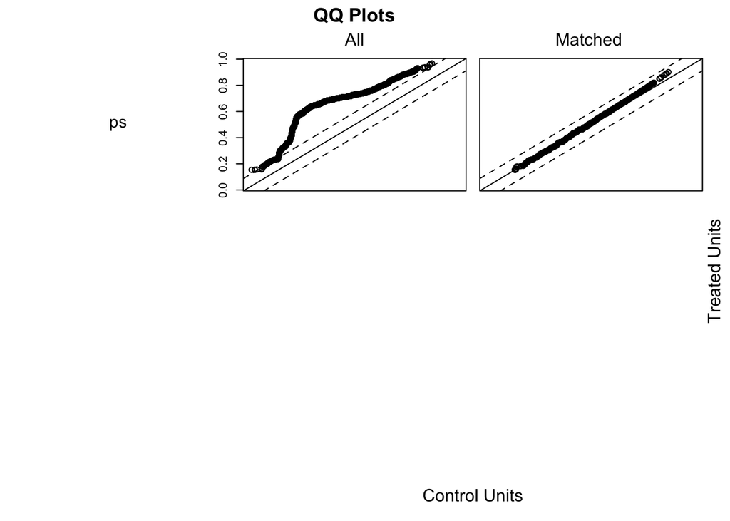

```r
plot(match.p)
```

```r
CreateTableOne(dat[rownames(dat) %in% c(rownames(match.p$match.matrix), match.p$match.matrix),],
               vars=c("age","sofa_first","chf_flg","gender_num", co_flg),
               strata=c("aline_flg"),test=FALSE) %>% print(
  printToggle      = FALSE,
  showAllLevels    = TRUE,
  cramVars         = "kon"
) %>%
{data.frame(
  variable_name             = gsub(" ", "&nbsp;", rownames(.), fixed = TRUE), .,
  row.names        = NULL,
  check.names      = FALSE,
  stringsAsFactors = FALSE)} %>%
knitr::kable()
```

| variable_name | level | 0 | 1 |
| --- | --- | --- | --- |
| n |  | 760 | 1393 |
| age (mean (sd)) |  | 62.43 (45.42) | 61.69 (40.74) |
| sofa_first (mean (sd)) |  | 2.56 (2.57) | 2.69 (2.71) |
| chf_flg (%) | 0 | 691 (90.9) | 1298 (93.2) |
|  | 1 | 69 ( 9.1) | 95 ( 6.8) |
| gender_num (%) | 0 | 323 (42.5) | 562 (40.3) |
|  | 1 | 437 (57.5) | 831 (59.7) |
| afib_flg (%) | 0 | 646 (85.0) | 1197 (85.9) |
|  | 1 | 114 (15.0) | 196 (14.1) |
| renal_flg (%) | 0 | 707 (93.0) | 1326 (95.2) |
|  | 1 | 53 ( 7.0) | 67 ( 4.8) |
| liver_flg (%) | 0 | 725 (95.4) | 1301 (93.4) |
|  | 1 | 35 ( 4.6) | 92 ( 6.6) |
| copd_flg (%) | 0 | 753 (99.1) | 1384 (99.4) |
|  | 1 | 7 ( 0.9) | 9 ( 0.6) |
| cad_flg (%) | 0 | 654 (86.1) | 1193 (85.6) |
|  | 1 | 106 (13.9) | 200 (14.4) |
| stroke_flg (%) | 0 | 637 (83.8) | 1141 (81.9) |
|  | 1 | 123 (16.2) | 252 (18.1) |
| mal_flg (%) | 0 | 663 (87.2) | 1192 (85.6) |
|  | 1 | 97 (12.8) | 201 (14.4) |
| resp_flg (%) | 0 | 501 (65.9) | 961 (69.0) |
|  | 1 | 259 (34.1) | 432 (31.0) |
| ards_flg (%) | 0 | 749 (98.6) | 1374 (98.6) |
|  | 1 | 11 ( 1.4) | 19 ( 1.4) |
| pneumonia_flg (%) | 0 | 628 (82.6) | 1173 (84.2) |
|  | 1 | 132 (17.4) | 220 (15.8) |

```r
outcome <- data.frame(aline_pt=dat[row.names(match.p$match.matrix), "hosp_exp_flg"],
                      match_pt=dat[match.p$match.matrix, "hosp_exp_flg"])
head(outcome)
```

```
##   aline_pt match_pt
## 1        0        0
## 2        0        0
## 3        0     <NA>
## 4        0        0
## 5        0     <NA>
## 6        0        0
```

```r
(tab <- table(outcome$aline_pt, outcome$match_pt, dnn=c("Aline","Matched Control")))
```

```
##      Matched Control
## Aline   0   1
##     0 562  93
##     1  91  14
```

```r
tab[1, 2] / tab[2, 1]
```

```
## [1] 1.021978
```

```r
paste("95% Confint", round(exp(c(log(tab[2, 1] / tab[1, 2]) - qnorm(0.975)*sqrt(1/tab[1, 2] + 1 / tab[2, 1]),
                                 log(tab[2, 1] / tab[1, 2]) + qnorm(0.975)*sqrt(1/tab[1, 2] + 1 / tab[2,1 ])) ),
                           2))
```

```
## [1] "95% Confint 0.73" "95% Confint 1.31"
```

```r
mcnemar.test(tab)
```

```
##
##  McNemar's Chi-squared test with continuity correction
##
## data:  tab
## McNemar's chi-squared = 0.0054348, df = 1, p-value = 0.9412
```

```r
# 0.5
set.seed(777)
match.p <- matchit(aline_flg2 ~ ps, data=dat[, c("aline_flg2","ps")], method="nearest", caliper=0.5)
match.p
```

```
##
## Call:
## matchit(formula = aline_flg2 ~ ps, data = dat[, c("aline_flg2",
##     "ps")], method = "nearest", caliper = 0.5)
##
## Sample sizes:
##           Control Treated
## All          1358    1393
## Matched       835     835
## Unmatched     523     558
## Discarded       0       0
```

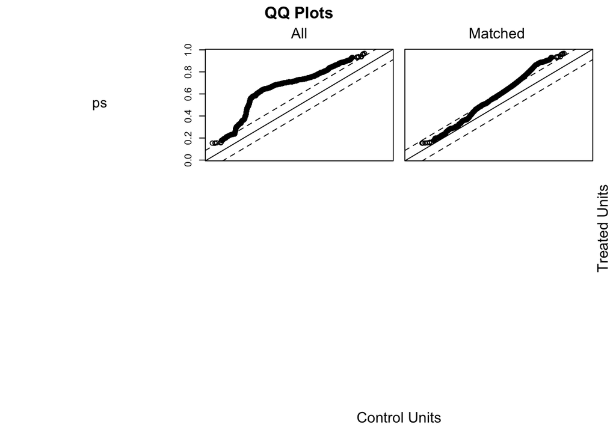

```r
plot(match.p)
```

```r
CreateTableOne(dat[rownames(dat) %in% c(rownames(match.p$match.matrix), match.p$match.matrix),],
               vars=c("age","sofa_first","chf_flg","gender_num", co_flg),
               strata=c("aline_flg"),test=FALSE) %>% print(
  printToggle      = FALSE,
  showAllLevels    = TRUE,
  cramVars         = "kon"
) %>%
{data.frame(
  variable_name             = gsub(" ", "&nbsp;", rownames(.), fixed = TRUE), .,
  row.names        = NULL,
  check.names      = FALSE,
  stringsAsFactors = FALSE)} %>%
knitr::kable()
```

| variable_name | level | 0 | 1 |
| --- | --- | --- | --- |
| n |  | 835 | 1393 |
| age (mean (sd)) |  | 64.06 (49.56) | 61.69 (40.74) |
| sofa_first (mean (sd)) |  | 2.63 (2.62) | 2.69 (2.71) |
| chf_flg (%) | 0 | 764 (91.5) | 1298 (93.2) |
|  | 1 | 71 ( 8.5) | 95 ( 6.8) |
| gender_num (%) | 0 | 342 (41.0) | 562 (40.3) |
|  | 1 | 493 (59.0) | 831 (59.7) |
| afib_flg (%) | 0 | 716 (85.7) | 1197 (85.9) |
|  | 1 | 119 (14.3) | 196 (14.1) |
| renal_flg (%) | 0 | 775 (92.8) | 1326 (95.2) |
|  | 1 | 60 ( 7.2) | 67 ( 4.8) |
| liver_flg (%) | 0 | 791 (94.7) | 1301 (93.4) |
|  | 1 | 44 ( 5.3) | 92 ( 6.6) |
| copd_flg (%) | 0 | 825 (98.8) | 1384 (99.4) |
|  | 1 | 10 ( 1.2) | 9 ( 0.6) |
| cad_flg (%) | 0 | 729 (87.3) | 1193 (85.6) |
|  | 1 | 106 (12.7) | 200 (14.4) |
| stroke_flg (%) | 0 | 703 (84.2) | 1141 (81.9) |
|  | 1 | 132 (15.8) | 252 (18.1) |
| mal_flg (%) | 0 | 707 (84.7) | 1192 (85.6) |
|  | 1 | 128 (15.3) | 201 (14.4) |
| resp_flg (%) | 0 | 554 (66.3) | 961 (69.0) |
|  | 1 | 281 (33.7) | 432 (31.0) |
| ards_flg (%) | 0 | 824 (98.7) | 1374 (98.6) |
|  | 1 | 11 ( 1.3) | 19 ( 1.4) |
| pneumonia_flg (%) | 0 | 688 (82.4) | 1173 (84.2) |
|  | 1 | 147 (17.6) | 220 (15.8) |

```r
outcome <- data.frame(aline_pt=dat[row.names(match.p$match.matrix), "hosp_exp_flg"],
                      match_pt=dat[match.p$match.matrix, "hosp_exp_flg"])
head(outcome)
```

```
##   aline_pt match_pt
## 1        0        0
## 2        0        0
## 3        0        0
## 4        0     <NA>
## 5        0        0
## 6        0        0
```

```r
(tab <- table(outcome$aline_pt, outcome$match_pt, dnn=c("Aline","Matched Control")))
```

```
##      Matched Control
## Aline   0   1
##     0 628  99
##     1  89  19
```

```r
tab[1, 2] / tab[2, 1]
```

```
## [1] 1.11236
```

```r
paste("95% Confint", round(exp(c(log(tab[2, 1] / tab[1, 2]) - qnorm(0.975)*sqrt(1/tab[1, 2] + 1 / tab[2, 1]),
                                 log(tab[2, 1] / tab[1, 2]) + qnorm(0.975)*sqrt(1/tab[1, 2] + 1 / tab[2,1 ])) ),
                           2))
```

```
## [1] "95% Confint 0.68" "95% Confint 1.2"
```

```r
mcnemar.test(tab)
```

```
##
##  McNemar's Chi-squared test with continuity correction
##
## data:  tab
## McNemar's chi-squared = 0.43085, df = 1, p-value = 0.5116
```